# AE_MNIST_03

Last update: 13.08.2018

This is my note on training Autoencoder using MNIST data set. It is more for demonstration how to make the implementation in Tensorflow rather than for any research purpose. However, it is another step in experimenting with Autoencoder and buidling my awarnes of how to use and play with Autoencoders. I use this as a foundation for personal research comming soon.

Here are main references I used to create my note:

- Here is the inspiration for my code: [aymericdamien/TensorFlow-Examples GitHub repository](https://github.com/aymericdamien/TensorFlow-Examples/blob/master/examples/3_NeuralNetworks/autoencoder.py)
- Gertjan van den Burg [blog post](https://gertjanvandenburg.com/blog/autoencoder/) on MNIST autoencoder and Tensorflow
- Useful post on how to use tensorboard for image visualisation [here](https://gist.github.com/jychstar/dc29b134f4fb14d9a0424af8ab659d7b)

#### Abstract

[figure not shown]

```python
import numpy as np
import matplotlib.pyplot as plt
import tensorflow as tf
#import pandas as pd           # (optional ?)
import imageio                # (optional) for saving images
from datetime import datetime # (optional)
from os.path import join      # (optional)
```

```python
print("Tensorflow version: ",tf.__version__)
```

```
Tensorflow version:  1.10.0
```

The reason I was considering using Tensorflow Data API are following messages.

```python
from tensorflow.examples.tutorials.mnist import input_data
mnist=input_data.read_data_sets("MNIST_data",one_hot=True)
```

[output not shown]

```python
print("Number of trainis samples:    ",mnist.train.num_examples)
print("Number of validation samples: ",mnist.validation.num_examples)
print("Number of test samples:       ",mnist.test.num_examples)
LOGDIR_ROOT = '/home/damian/GitRepositories/Autoencoders/AE_MNIST/log_01'  # for tensorboard logs
```

```
Number of trainis samples:     55000
Number of validation samples:  5000
Number of test samples:        10000
```

This is an example of how single image looks like. When looking on values they are between 0 and 1. It means MNIST data set available through tensorflow has already rescaled values from oryginl one which are between 0 and 255.

```
Shape of the sample:  (1, 784) ,  Label (digit):  [[6]]
```

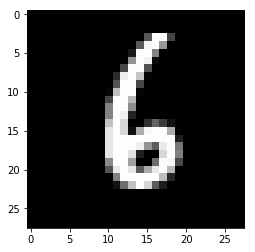

```python
ToShow_x, ToShow_y = mnist.test.next_batch(1)
print("Shape of the sample: ",Tmp_x.shape,",  Label (digit): ",(np.where(ToShow_y==1)[1]).reshape(-1,1))
fig_ToShow_x = ToShow_x.reshape([28,28])
plt.imshow(fig_ToShow_x, origin="upper", cmap="gray")
plt.show()
```

And here is view after short training bow the above digits is recosntructed. Please note that trainins for the below reconstruction was very short (4800 steps, 500 samples for batch size).

[figure not shown]

Below, I have chosen layers dimensions arbitraly. Each leyer has different number of nodes. However, I saw implementation (for example here) where two hiden layers of encoder and two hidden layers of decoder have the same number of nodes (for example 50 nodes).

```python
# Network dimensionality
Net_size = {\
            'size_input'    : 784, # MNIST data input (img shape: 28*28)
            'size_output'   : 784,
            'size_hid_1' : 256, # 1st layer num features
            'size_hid_2' : 128, # 2nd layer num features (the latent dim)
            'size_hid_3' : 32,
            'size_hid_4' : 2 }
```

```python
theSeed = 110
tf.reset_default_graph()  # To avoid many duplicated nodes in the default grpah
tf.set_random_seed(theSeed)
```

```python
# tf Graph input (only pictures)
X = tf.placeholder("float", [None, Net_size['size_input']])
```

```python
def encoder(x, NetSize):
    actFunc = tf.nn.sigmoid
    #he_init = tf.contrib.layers.variance_scaling_initializer() # HE initialization for ReLu or ELU
    # Dense layer by default uses Xavier initialization
    hidden_1 = tf.layers.dense(x,NetSize['size_hid_1'], activation=actFunc, name='Enc_Hid_1')
    hidden_2 = tf.layers.dense(hidden_1,NetSize['size_hid_2'], activation=actFunc, name='Enc_Hid_2')
    hidden_3 = tf.layers.dense(hidden_2,NetSize['size_hid_3'], activation=actFunc, name='Enc_Hid_3')
    hidden_4 = tf.layers.dense(hidden_3,NetSize['size_hid_4'], activation=actFunc, name='Enc_Hid_4')
    return hidden_4
```

```python
def decoder(x,NetSize):
    actFunc = tf.nn.sigmoid
    #he_init = tf.contrib.layers.variance_scaling_initializer() # HE initialization for ReLu or ELU
    # Dense layer by default uses Xavier initialization
    hidden_1 = tf.layers.dense(x, NetSize['size_hid_3'], activation=actFunc, name='Dec_Hid_1')
    hidden_2 = tf.layers.dense(hidden_1, NetSize['size_hid_2'], activation=actFunc, name='Dec_Hid_2')
    hidden_3 = tf.layers.dense(hidden_2, NetSize['size_hid_1'], activation=actFunc, name='Dec_Hid_3')
    hidden_4 = tf.layers.dense(hidden_3, NetSize['size_output'], activation=actFunc, name='Dec_Hid_4')
    return hidden_4
```

```python
# Construct model
encoder_op = encoder(X, Net_size)
decoder_op = decoder(encoder_op, Net_size)

# Prediction
y_pred = decoder_op
# Targets (Labels) are the input data
y_true = X
```

```python
# Training Parameters
learning_rate = 0.01

# Define loss and optimizer, minimize the squared error
loss = tf.reduce_mean(tf.pow(y_true - y_pred, 2))
optimizer = tf.train.AdamOptimizer(learning_rate).minimize(loss)

# Initialize the variables (i.e. assign their default value)
init = tf.global_variables_initializer()
```

```python
# Training Parameters
num_steps = 24000   # Number of training iterations
batch_size = 500  # Numbe of samples for each training iteration
display_step = 1000 # Every display_step print MSE train error
examples_to_show = 10
```

```python
now = datetime.utcnow().strftime("%Y%m%d%H%M")
LOGDIR = join(LOGDIR_ROOT,now)   # Create a log directory with date and time stamp (with minutes resolution)

def create_summaries(inLoss, x_in, x_out, LogDir):
    writer = tf.summary.FileWriter(LogDir, tf.get_default_graph())
    tf.summary.scalar("Loss", loss)
    tf.summary.image("Input", tf.reshape(x_in, [-1, 28, 28, 1]))
    tf.summary.image("Onput", tf.reshape(x_out, [-1, 28, 28, 1]))
    #tf.summary.image('Latent', tf.reshape(latent, [-1, 2, 1, 1]))
    return writer, tf.summary.merge_all()
```

```
Step 1: Minibatch Loss: 0.237862
Step 1000: Minibatch Loss: 0.052252
Step 2000: Minibatch Loss: 0.044720
Step 3000: Minibatch Loss: 0.044566
Step 4000: Minibatch Loss: 0.044758
Step 5000: Minibatch Loss: 0.045284
Step 6000: Minibatch Loss: 0.042413
Step 7000: Minibatch Loss: 0.042611
Step 8000: Minibatch Loss: 0.043812
Step 9000: Minibatch Loss: 0.043282
Step 10000: Minibatch Loss: 0.044189
Step 11000: Minibatch Loss: 0.043674
Step 12000: Minibatch Loss: 0.043972
Step 13000: Minibatch Loss: 0.041723
Step 14000: Minibatch Loss: 0.042874
Step 15000: Minibatch Loss: 0.042954
Step 16000: Minibatch Loss: 0.043842
Step 17000: Minibatch Loss: 0.041173
Step 18000: Minibatch Loss: 0.041228
Step 19000: Minibatch Loss: 0.041828
Step 20000: Minibatch Loss: 0.042442
Step 21000: Minibatch Loss: 0.042284
Step 22000: Minibatch Loss: 0.043326
Step 23000: Minibatch Loss: 0.044601
Step 24000: Minibatch Loss: 0.040685
Original Images
```

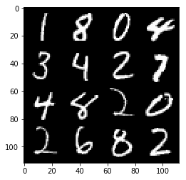

```
Reconstructed Images
```

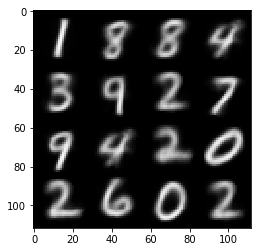

```python
writer, summary_op = create_summaries(loss, X, y_pred, LOGDIR)
# Start Training
with tf.Session() as sess:

    # Run the initializer
    sess.run(init)

    # Training
    for i in range(1, num_steps+1):

        # Get the next batch of MNIST data (only images are needed, not labels)
        # shuffle=False - for experimentation
        batch_x, batch_y = mnist.train.next_batch(batch_size,shuffle=False)
        # Run optimization op (backprop) and cost op (to get loss value)
        _, l = sess.run([optimizer, loss], feed_dict={X: batch_x})

        # Display logs per step
        if i % display_step == int(0) or i == int(1):
            print('Step %i: Minibatch Loss: %f' % (i, l))
            summary = summary_op.eval(feed_dict={X: np.reshape(ToShow_x[0],[-1,784])})
            writer.add_summary(summary, i)
            writer.flush()

    # Testing
    # Encode and decode images from test set and visualize their reconstruction.
    n = 4
    canvas_orig = np.empty((28 * n, 28 * n))
    canvas_recon = np.empty((28 * n, 28 * n))
    for i in range(n):
        # MNIST test set
        batch_x, _ = mnist.test.next_batch(n)
        # Encode and decode the digit image
        g = sess.run(decoder_op, feed_dict={X: batch_x})

        # Display original images
        for j in range(n):
            # Draw the original digits
            canvas_orig[i * 28:(i + 1) * 28, j * 28:(j + 1) * 28] = \
                batch_x[j].reshape([28, 28])
        # Display reconstructed images
        for j in range(n):
            # Draw the reconstructed digits
            canvas_recon[i * 28:(i + 1) * 28, j * 28:(j + 1) * 28] = \
                g[j].reshape([28, 28])

    print("Original Images")
    plt.figure(figsize=(n, n))
    plt.imshow(canvas_orig, origin="upper", cmap="gray")
    plt.show()
    #imageio.imwrite('oryginal.jpg', canvas_orig)

    print("Reconstructed Images")
    plt.figure(figsize=(n, n))
    plt.imshow(canvas_recon, origin="upper", cmap="gray")
    plt.show()
    #imageio.imwrite('reconstructed.jpg', canvas_recon)
```

The example of test samples shows that number of iteration is not enough to correctly reconstruct all digits. For example number 8 is reconstructed to 0 and number 0 is reoconstructed to 8. This sugests that the latent space for these two number overlaps. But the overlapping is partial as we can see that other number 8 is correctly reconstructed into number 8. Another reconstruction problems appears with number 4 which is reconstructed two times into number 9.

Here are not strictly related references or simply links to content that can be inspiring for further work:

- At some point I was considering to use following reference to apply Tensorflow Data API. I have reseigned from doing so temporarily. However, I think [Tensorflow Data API](http://cjalmeida.net/post/tensorflow-mnist/) blog post can be useful
- for further reading about [variational autoencoder](https://www.kaggle.com/rvislaywade/visualizing-mnist-using-a-variational-autoencoder)
- Collection of GitHub repositories as an [inspiration](https://github.com/aqibsaeed) for further work